# Brief description of the members of Davos

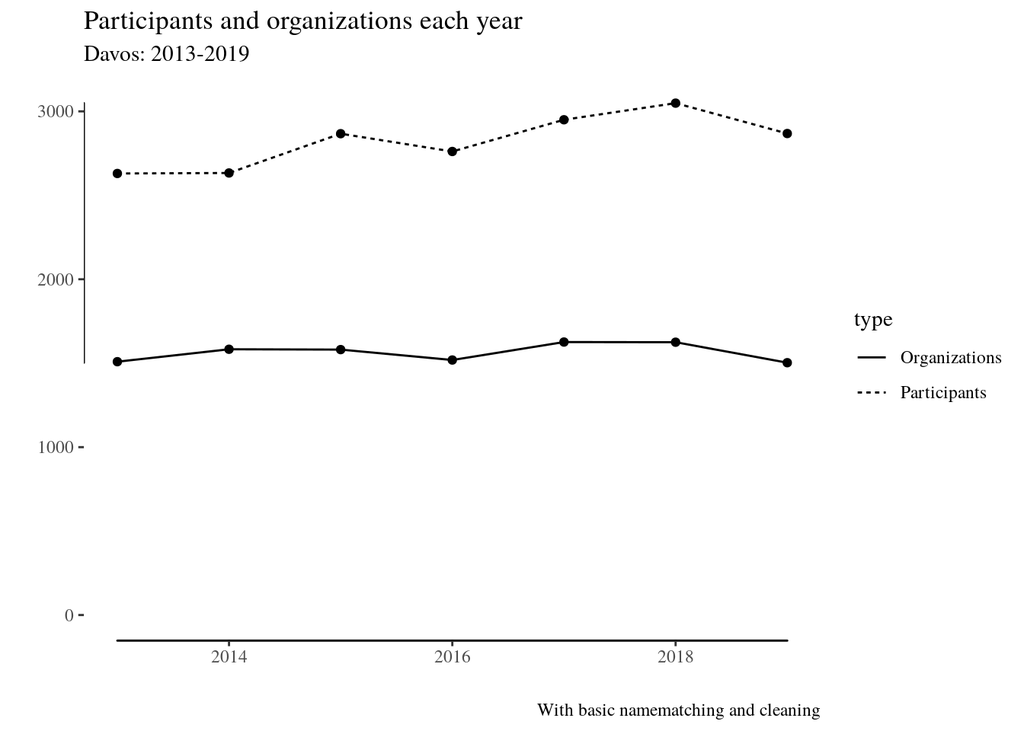

## Participants and organizations for select countries

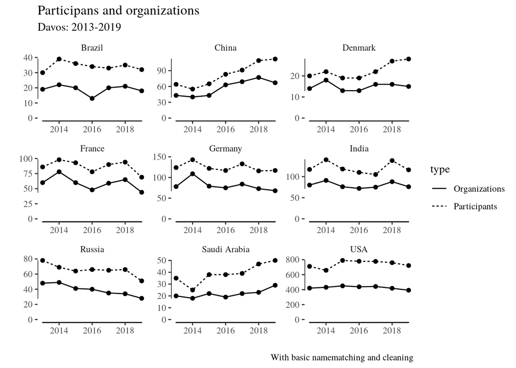

## New members

Here we see how many new organizations and individuals that participate in Davos. This tells us how many new members we should expect for each additional year and whether we have a file that matches completely wrong. And basically it says that each year has pretty much the same amount of new members and organizations. So - nothing to see here :-)

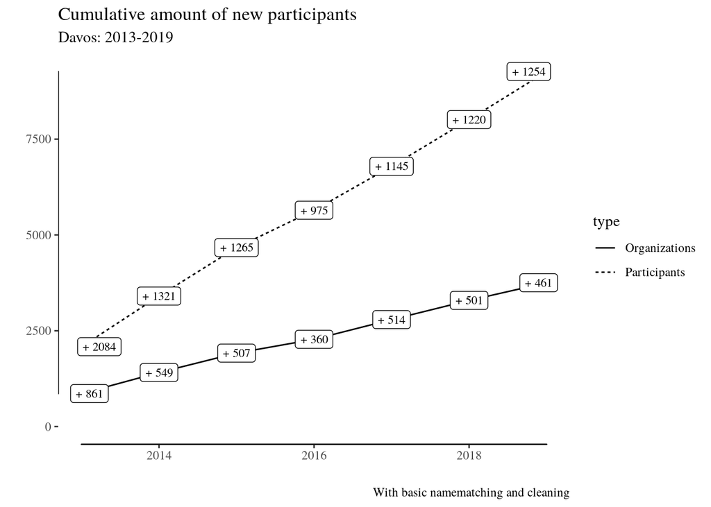

# Selection criteria

Here we define the selection criteria. We cannot assume a simple relationship between global prominence and number of participants. The dividing line is whether the organization has a stable and strong engagement with the WEF. At the practical level we would prefer a population of less than 500 organizations.

### Number of active years.

The duration of the engagement with the WEF is calculated by the number of years they are present. This measure underestimates the number of active years if we have not cleaned the name of the organization properly. An organization might have merged or changed its name and thereby not be correctly registered.

|  | Active Years | Organizations | Share | Cumulative org |
| --- | --- | --- | --- | --- |
| 7 | 7 | 567 | 15.1% | 567 |
| 6 | 6 | 210 | 5.6% | 777 |
| 5 | 5 | 229 | 6.1% | 1006 |
| 4 | 4 | 218 | 5.8% | 1224 |
| 3 | 3 | 314 | 8.4% | 1538 |
| 2 | 2 | 543 | 14.5% | 2081 |
| 1 | 1 | 1672 | 44.6% | 3753 |

### Number of unique members

If an organization is only represented by a single person, then it may reflect the idiosyncracies of their current leader and not a lasting engagement. A large entourage indicates that the organization is lobbying or networking broadly, that it is looking for customers etc.  
Here we are vulnerable to names being spelled differently and we are therefore overestimating the number of unique participants.

|  | Active members | Organizations | Share | Cumulative org |
| --- | --- | --- | --- | --- |
| 42 | 111 | 1 | 0.0% | 1 |
| 41 | 100 | 1 | 0.0% | 2 |
| 40 | 61 | 1 | 0.0% | 3 |
| 39 | 51 | 1 | 0.0% | 4 |
| 38 | 49 | 1 | 0.0% | 5 |
| 37 | 48 | 1 | 0.0% | 6 |
| 36 | 44 | 1 | 0.0% | 7 |
| 35 | 39 | 1 | 0.0% | 8 |
| 34 | 36 | 2 | 0.1% | 10 |
| 33 | 34 | 2 | 0.1% | 12 |
| 32 | 33 | 4 | 0.1% | 16 |
| 31 | 32 | 1 | 0.0% | 17 |
| 30 | 31 | 2 | 0.1% | 19 |
| 29 | 30 | 1 | 0.0% | 20 |
| 28 | 29 | 1 | 0.0% | 21 |
| 27 | 27 | 3 | 0.1% | 24 |
| 26 | 26 | 2 | 0.1% | 26 |
| 25 | 25 | 3 | 0.1% | 29 |
| 24 | 24 | 1 | 0.0% | 30 |
| 23 | 23 | 7 | 0.2% | 37 |
| 22 | 22 | 5 | 0.1% | 42 |
| 21 | 21 | 4 | 0.1% | 46 |
| 20 | 20 | 4 | 0.1% | 50 |
| 19 | 19 | 7 | 0.2% | 57 |
| 18 | 18 | 9 | 0.2% | 66 |
| 17 | 17 | 12 | 0.3% | 78 |
| 16 | 16 | 15 | 0.4% | 93 |
| 15 | 15 | 7 | 0.2% | 100 |
| 14 | 14 | 16 | 0.4% | 116 |
| 13 | 13 | 9 | 0.2% | 125 |
| 12 | 12 | 16 | 0.4% | 141 |
| 11 | 11 | 25 | 0.7% | 166 |
| 10 | 10 | 20 | 0.5% | 186 |
| 9 | 9 | 25 | 0.7% | 211 |
| 8 | 8 | 27 | 0.7% | 238 |
| 7 | 7 | 46 | 1.2% | 284 |
| 6 | 6 | 74 | 2.0% | 358 |
| 5 | 5 | 75 | 2.0% | 433 |
| 4 | 4 | 145 | 3.9% | 578 |
| 3 | 3 | 261 | 7.0% | 839 |
| 2 | 2 | 569 | 15.2% | 1408 |
| 1 | 1 | 2345 | 62.5% | 3753 |

### Currently active

|  | Present years | Organizations | Share | Cumulative org |
| --- | --- | --- | --- | --- |
| 4 | 3 | 934 | 24.9% | 934 |
| 3 | 2 | 444 | 11.8% | 1378 |
| 2 | 1 | 1064 | 28.4% | 2442 |
| 1 | 0 | 1311 | 34.9% | 3753 |

### Several members in the same year

Some organizations only send their CEO, but they do so consistently over a long period. If they change their CEO several times over the period or their CEO is registered with a different name, then their total number of participants might not reflect the intensity of their investment in WEF. This variable measures how many years they did send more than a single individiual.

|  | Present years | Organizations | Share | Cumulative org |
| --- | --- | --- | --- | --- |
| 8 | 7 | 199 | 5.3% | 199 |
| 7 | 6 | 83 | 2.2% | 282 |
| 6 | 5 | 82 | 2.2% | 364 |
| 5 | 4 | 88 | 2.3% | 452 |
| 4 | 3 | 115 | 3.1% | 567 |
| 3 | 2 | 154 | 4.1% | 721 |
| 2 | 1 | 292 | 7.8% | 1013 |
| 1 | 0 | 2740 | 73.0% | 3753 |

# Scenarios

We combine the four measures in two scenarios: **A: Strong current presence** and **B: Enduring presence**. In scenario A we want to include organizations that have a strong presence in the recent years. Scenario **A** requires at least 4 different members, attendance in the last three years and at least 1 year with more than 1 member. Scenario **B** requires attendance in at least 6 out of 7 years, at least 3 different members and at least three years with more than 2 members.

Scenario A: Strong current presence

| scenario.a | Freq |
| --- | --- |
| FALSE | 3333 |
| TRUE | 420 |

Scenario B: Enduring presence

| scenario.b | Freq |
| --- | --- |
| FALSE | 3345 |
| TRUE | 408 |

Either scenario

| Var1 | Freq |
| --- | --- |
| FALSE | 3264 |
| TRUE | 489 |

Scenario A vs. Scenario B

|  | FALSE | TRUE |
| --- | --- | --- |
| FALSE | 3264 | 69 |
| TRUE | 81 | 339 |

In total we end up with 489 organizations that satisfy one of the scenarios. The vast majority satisfy both scenarios.

# Data table

You can see the different organizations and whether they fall for the criteria in the table below.

|  | Organization | Active years | Active (17-19) | Unique members | Years with at least 2 members | Positions | In sample | Country | Sector (Business, State, Academia, Media, International organisation) | Subsector | Note | Change to | Present scenario | Enduring scenario | Members |
| --- | --- | --- | --- | --- | --- | --- | --- | --- | --- | --- | --- | --- | --- | --- | --- |
| 1 | World Economic Forum | 6 | 3 | 111 | 6 | 313 | TRUE |  | IO | Think Tank |  |  | True | True | Adrian Monck * Akira Tsuchiya * Alan Marcus * Alex Wong * Alois Zwinggi * Anders Borg * Anil Menon * Anja Kaspersen * Anne Toth * Arnaud Bernaert * Arne Cartridge * Børge Brende * Cheryl Martin * Chri… |
| 2 | Government: Switzerland | 7 | 3 | 100 | 7 | 214 | TRUE |  | Government | Nation state |  |  | True | True | Mario Fehr * Thomas Heiniger * Alain Berset * André Blattmann * Barbara Janom Steiner * Bastien Girod * Beat Walti * Benoit Revaz * Carmen Elfriede Walker Späh * Carmen Walker Späh * Céline Amaudruz *… |
| 3 | Government: USA | 7 | 3 | 83 | 7 | 122 | TRUE |  | Government | Nation state |  |  | True | True | Alan D. Cohn * Ander Crenshaw * Anthony Scaramucci * Bob Corker * Bruce Andrews * Bruce Swartz * Carolyn B. Maloney * Catherine Novelli * Christopher Coons * Christopher P. Liddell * Christopher Van H… |
| 4 | Government: USA - Republican party | 6 | 2 | 20 | 5 | 38 | TRUE(ADDED) |  | Government | Party |  |  |  |  |  |
| 5 | Government: USA - Democratic party | 6 | 2 | 14 | 4 | 16 | TRUE(ADDED) |  | Government | Party |  |  |  |  |  |
| 6 | United Nations | 7 | 3 | 69 | 7 | 135 | TRUE |  | IO | IO |  |  | True | True | Achim Steiner * Alicia Bárcena Ibarra * Amandeep Singh Gill * Anthony Lake * Antónia Mészáros * Antonio Guterres * Audrey Azoulay * Babatunde Osotimehin * Ban Ki-moon * Baroness Valerie Amos * Carlos … |
| 7 | United Nations - UNICEF | 6 | 3 | 6 | 3 | 10 | TRUE(ADDED) |  | IO | IO |  |  |  |  |  |
| 8 | United Nations - UNHCR | 6 | 3 | 4 | 1 | 8 | TRUE(ADDED) |  | IO | IO |  |  |  |  |  |
| 9 | United Nations - UNDP | 5 | 3 | 4 | 1 | 7 | TRUE(ADDED) |  | IO | IO |  |  |  |  |  |
| 10 | - | 7 | 3 | 51 | 7 | 61 | TRUE |  | NA |  |  |  | True | True | Amy J.C. Cuddy * Angelique Kidjo * Anne-Sophie Mutter * Brian Skerry * Cory Doctorow * David Nabarro * Diana Kozikova * Elif Shafak * Eric Whitacre * Feras Fayyad * Franziska Frutiger * Gabriela Monte… |

[output cut: 3745 more lines]